# Homework-Week-6

# 1

```r
z.prop.test <- function(p1, p2, p0, n1, n2, alternative = "two.tailed", alpha = 0.05, k = 1000){
 p <- rep(NA, k)
 for (i in 1:k){
  p2 <- NULL
  n2 <- NULL

  z <- (p2-p1)/sqrt((p0*(1-p0))*((1/n1)+(1/n2)))
  z1p <- (p1-p0)/(sqrt((p0*(1-p0))/n1))
  if (alternative == "less") {
            p[i] <- pnorm(z, lower.tail = TRUE)
  }
   if (alternative == "greater") {
            p[i] <- pnorm(z, lower.tail = FALSE)}
  if (alternative == "two.tailed") {
    if (z > 0)
                {
                  p[i] <- 2 * pnorm(z, lower.tail = FALSE)
            }
    if (z < 0)
                {
                  p[i] <- 2 * pnorm(z, lower.tail = TRUE)
    }
  }
 }
if (p2 == NULL){
  z1p
}
 if (alternative == "less") {
            p[i] <- pnorm(z1p, lower.tail = TRUE)
 }
 if (alternative == "greater") {
            p[i] <- pnorm(z1p, lower.tail = FALSE)
 }
 if (alternative == "two.tailed") {
            if (z1p > 0)
                {
                  p[i] <- 2 * pnorm(z1p, lower.tail = FALSE)
                }
            if (z1p < 0)
                {
                  p[i] <- 2 * pnorm(z1p, lower.tail = TRUE)
                }
        }

if (n2 == NULL){
  z1p
}
 if (alternative == "less") {
            p[i] <- pnorm(z1p, lower.tail = TRUE)
 }
 if (alternative == "greater") {
            p[i] <- pnorm(z1p, lower.tail = FALSE)
 }
 if (alternative == "two.tailed") {
            if (z1p > 0)
                {
                  p[i] <- 2 * pnorm(z1p, lower.tail = FALSE)
                }
            if (z1p < 0)
                {
                  p[i] <- 2 * pnorm(z1p, lower.tail = TRUE)
                }
        }
if (n1*p1 > 5){"warning: n*p is less than 5 it fails the assumption that it is normal" }
if (n1*(1-p1) >5){"warning: n*(1-p) is less than it fails the assumption that it is normal"}

a <- 0.05 #this is alpha
cva <- qnorm(1-a/2)
cvofp1<-((p1*(1-p1))/n1)
cvofp2<-((p2*(1-p2))/n2)
cvsqrt<-sqrt(cvofp1+cvofp2)
se<-cva*cvsqrt
p1p2 <- p1+p2
cvlower<- p1p2-se
cvupper <- p1p2+se
cv <- c(cvlower, cvupper)
cv


return(z)
return(cv)
return(p[i])#done after 2
#I'm trying to find out how to get the right responces here but something isn't working. I also dont know how to get the appropreate p value for each of the different casses but I'm still working on this. This homework is kind of hard. I'm still working on part two.
}
```

# 2

All of this is just the regular thing not the log part

```r
library(curl)
library(ggplot2)
f <- curl("https://raw.githubusercontent.com/fuzzyatelin/fuzzyatelin.github.io/master/AN597_Fall17/KamilarAndCooperData.csv")
d <- read.csv(f, header = TRUE, sep = ",", stringsAsFactors = FALSE)
head(d)
```

```
##               Scientific_Name          Family          Genus      Species
## 1 Allenopithecus_nigroviridis Cercopithecidae Allenopithecus nigroviridis
## 2         Allocebus_trichotis Cercopithecidae      Allocebus    trichotis
## 3           Alouatta_belzebul        Atelidae       Alouatta     belzebul
## 4             Alouatta_caraya        Atelidae       Alouatta       caraya
## 5            Alouatta_guariba        Atelidae       Alouatta      guariba
## 6           Alouatta_palliata        Atelidae       Alouatta     palliata
##   Brain_Size_Species_Mean Brain_Size_Female_Mean   Brain_size_Ref
## 1                   58.02                  53.70 Isler et al 2008
## 2                      NA                     NA
## 3                   52.84                  51.19 Isler et al 2008
## 4                   52.63                  47.80 Isler et al 2008
## 5                   51.70                  49.08 Isler et al 2008
## 6                   49.88                  48.04 Isler et al 2008
##   Body_mass_male_mean Body_mass_female_mean Mass_Dimorphism
```

[output cut: 69 more lines]

This is as far as I got as of 2, any changes after this were done after , and anything above this that is changed will have a note saying it was changed after

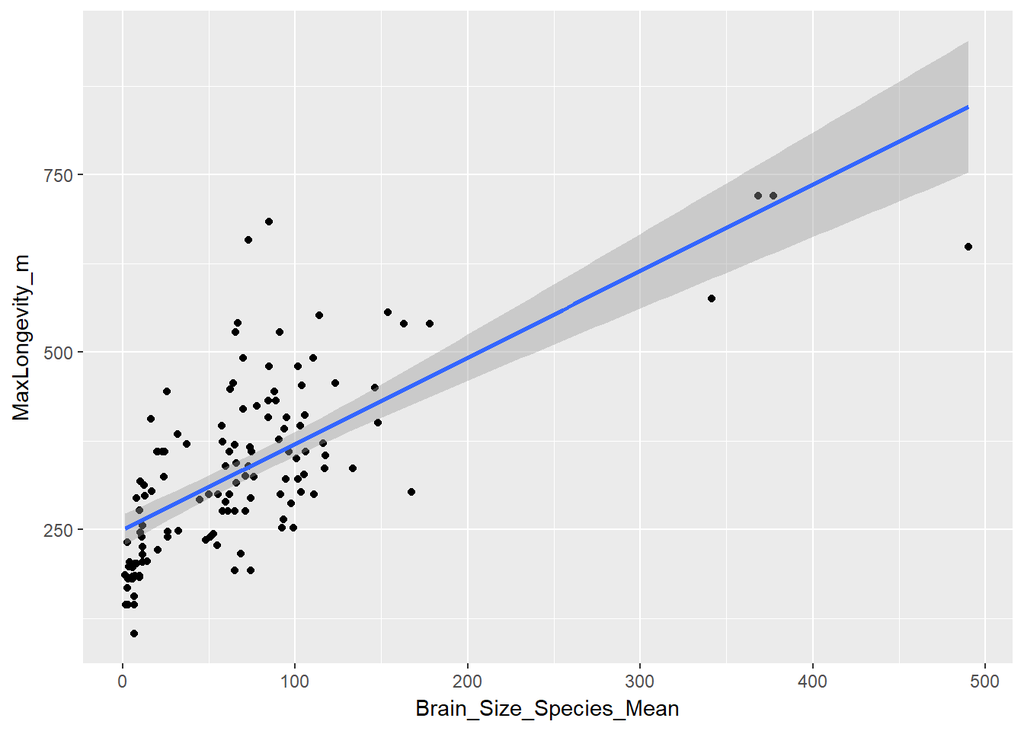

```r
g <- ggplot(data = d, aes(x = Brain_Size_Species_Mean, y = MaxLongevity_m))
g <- g + geom_point()
g <- g + geom_smooth(method = "lm", formula = y ~ x)
g
```

I an a little confused about the geom_text() funtion, I can’t find it

```r
d2 <- na.omit(d)
head(d2)
```

```
##        Scientific_Name          Family         Genus   Species
## 6    Alouatta_palliata        Atelidae      Alouatta  palliata
## 8   Alouatta_seniculus        Atelidae      Alouatta seniculus
## 37  Callithrix_jacchus         Cebidae    Callithrix   jacchus
## 43     Cebus_capucinus         Cebidae         Cebus capucinus
## 58 Cercopithecus_mitis Cercopithecidae Cercopithecus     mitis
## 74     Colobus_guereza Cercopithecidae       Colobus   guereza
##    Brain_Size_Species_Mean Brain_Size_Female_Mean   Brain_size_Ref
## 6                    49.88                  48.04 Isler et al 2008
## 8                    55.22                  54.26 Isler et al 2008
## 37                    7.24                   7.05 Isler et al 2008
## 43                   72.93                  72.12 Isler et al 2008
## 58                   71.33                  65.24 Isler et al 2008
## 74                   74.39                  69.77 Isler et al 2008
##    Body_mass_male_mean Body_mass_female_mean Mass_Dimorphism
```

[output cut: 69 more lines]

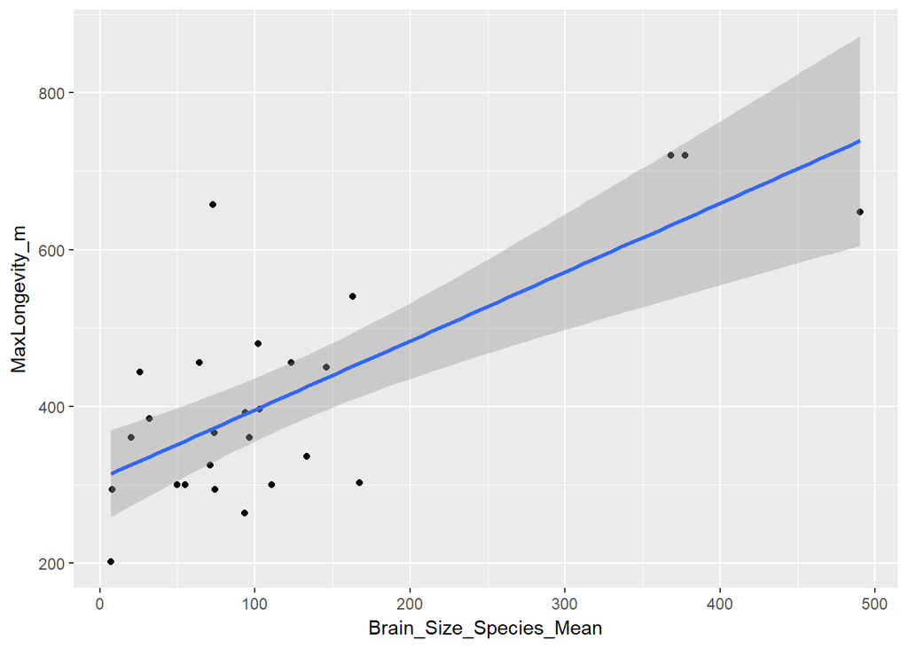

```r
g <- ggplot(data = d2, aes(x = Brain_Size_Species_Mean, y = MaxLongevity_m))
g <- g + geom_point()
g <- g + geom_smooth(method = "lm", formula = y ~ x)
g
```

```r
l <- d2$MaxLongevity_m
b <- d2$Brain_Size_Species_Mean
beta1 <- cor(b, l) * (sd(l)/sd(b))
beta1
```

```
## [1] 0.8789037
```

```r
fit<-lm(l~b)
summary(fit)
```

```
##
## Call:
## lm(formula = l ~ b)
##
## Residuals:
##      Min       1Q   Median       3Q      Max
## -152.498  -73.422   -4.425   72.430  285.749
##
## Coefficients:
##             Estimate Std. Error t value Pr(>|t|)
## (Intercept) 307.7522    27.8459  11.052 6.73e-11 ***
## b             0.8789     0.1672   5.256 2.18e-05 ***
## ---
## Signif. codes:  0 '***' 0.001 '**' 0.01 '*' 0.05 '.' 0.1 ' ' 1
##
## Residual standard error: 98.31 on 24 degrees of freedom
## Multiple R-squared:  0.5351, Adjusted R-squared:  0.5158
## F-statistic: 27.63 on 1 and 24 DF,  p-value: 2.176e-05
```

I think using this function thing summary you can test the Ho and the Ha, we know that our alpha is 0.1 and our p value for slope is 2.176e-05 which is less than alpha we we reject ho. I think this is how you want us to test this. But I dont know how to set the alpha level.

```r
confint(fit, 'b', level=0.90)
```

```
##         5 %     95 %
## b 0.5928154 1.164992
```

I think this is the 90% ci for the slope

```r
confint(fit, level=0.90)
```

```
##                     5 %       95 %
## (Intercept) 260.1112167 355.393214
## b             0.5928154   1.164992
```

```r
ci <- predict(fit, newdata = data.frame(Brain_Size_Species_Mean = d2$Brain_Size_Species_Mean), interval = "confidence",
    level = 0.90)  # for a vector of values
head(ci)
```

```
##        fit      lwr      upr
## 1 351.5919 312.9621 390.2217
## 2 356.2853 318.4280 394.1425
## 3 314.1155 267.9467 360.2843
## 4 371.8507 336.2051 407.4962
## 5 370.4444 334.6229 406.2659
## 6 373.1339 337.6445 408.6232
```

```r
fit<-lm(l~b)
h_hat <- predict(fit, newdata = data.frame(Brain_Size_Species_Mean = d2$Brain_Size_Species_Mean))
df <- data.frame(cbind(d2$Brain_Size_Species_Mean, d2$MaxLongevity_m, h_hat))
names(df) <- c("x", "y", "yhat")
head(df)
```

```
##       x     y     yhat
## 1 49.88 300.0 351.5919
## 2 55.22 300.0 356.2853
## 3  7.24 201.6 314.1155
## 4 72.93 657.6 371.8507
## 5 71.33 325.2 370.4444
## 6 74.39 294.0 373.1339
```

```r
df <- cbind(df, ci)
names(df) <- c("x", "y", "yhat", "CIfit", "CIlwr", "CIupr")
head(df)
```

```
##       x     y     yhat    CIfit    CIlwr    CIupr
## 1 49.88 300.0 351.5919 351.5919 312.9621 390.2217
## 2 55.22 300.0 356.2853 356.2853 318.4280 394.1425
## 3  7.24 201.6 314.1155 314.1155 267.9467 360.2843
## 4 72.93 657.6 371.8507 371.8507 336.2051 407.4962
## 5 71.33 325.2 370.4444 370.4444 334.6229 406.2659
## 6 74.39 294.0 373.1339 373.1339 337.6445 408.6232
```

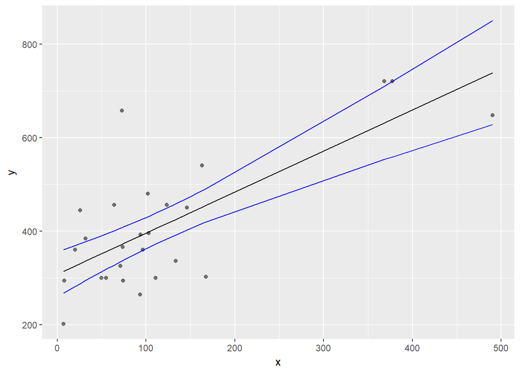

```r
g <- ggplot(data = df, aes(x = x, y = y))
g <- g + geom_point(alpha = 1/2)
g <- g + geom_line(aes(x = x, y = CIfit), colour = "black")
g <- g + geom_line(aes(x = x, y = CIlwr), colour = "blue")
g <- g + geom_line(aes(x = x, y = CIupr), colour = "blue")
g
```

```r
pi <- predict(fit, newdata = data.frame(Brain_Size_Species_Mean = d2$Brain_Size_Species_Mean), interval = "prediction",
    level = 0.90)  # for a vector of values
head(pi)
```

```
##        fit      lwr      upr
## 1 351.5919 179.0151 524.1688
## 2 356.2853 183.8797 528.6908
## 3 314.1155 139.6963 488.5347
## 4 371.8507 199.9172 543.7841
## 5 370.4444 198.4744 542.4144
## 6 373.1339 201.2328 545.0350
```

```r
df <- cbind(df, pi)
names(df) <- c("x", "y", "yhat", "CIfit", "CIlwr", "CIupr", "PIfit", "PIlwr",
    "PIupr")
head(df)
```

```
##       x     y     yhat    CIfit    CIlwr    CIupr    PIfit    PIlwr
## 1 49.88 300.0 351.5919 351.5919 312.9621 390.2217 351.5919 179.0151
## 2 55.22 300.0 356.2853 356.2853 318.4280 394.1425 356.2853 183.8797
## 3  7.24 201.6 314.1155 314.1155 267.9467 360.2843 314.1155 139.6963
## 4 72.93 657.6 371.8507 371.8507 336.2051 407.4962 371.8507 199.9172
## 5 71.33 325.2 370.4444 370.4444 334.6229 406.2659 370.4444 198.4744
## 6 74.39 294.0 373.1339 373.1339 337.6445 408.6232 373.1339 201.2328
##      PIupr
## 1 524.1688
## 2 528.6908
## 3 488.5347
## 4 543.7841
## 5 542.4144
## 6 545.0350
```

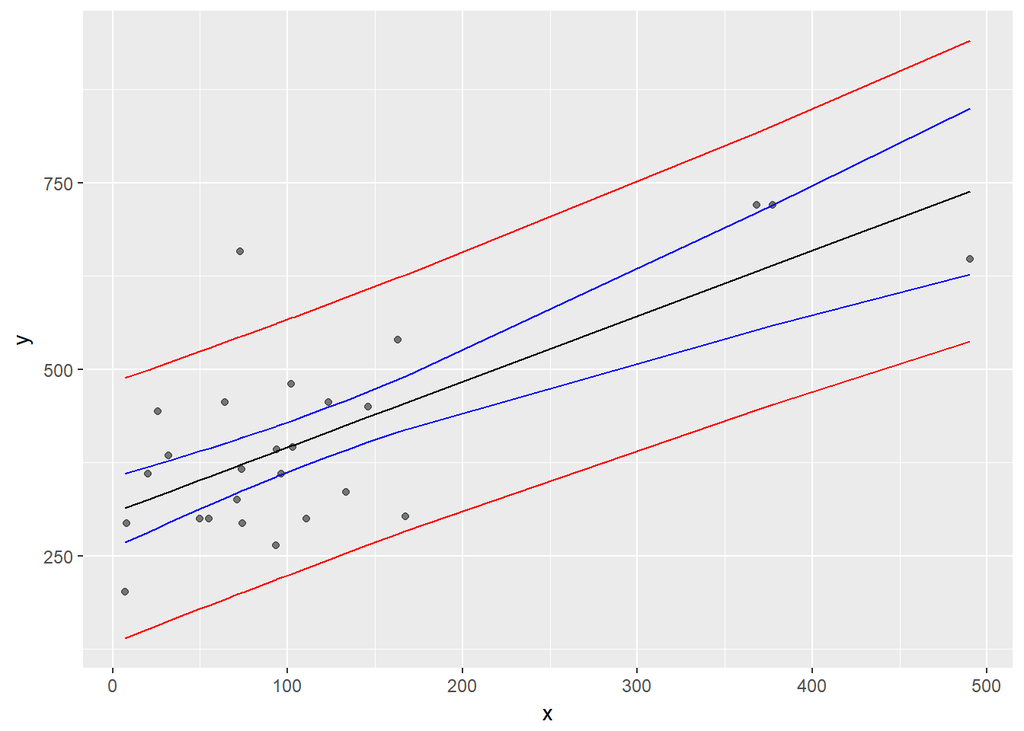

```r
g <- g + geom_line(data = df, aes(x = x, y = PIlwr), colour = "red")
g <- g + geom_line(data = df, aes(x = x, y = PIupr), colour = "red")
g
```

```r
pi <- predict(fit, newdata = data.frame(Brain_Size_Species_Mean = 800), interval = "prediction",
    level = 0.95)  # for a single value
pi
```

```
##         fit      lwr      upr
## 1  351.5919 143.4063 559.7776
## 2  356.2853 148.3063 564.2643
## 3  314.1155 103.7073 524.5236
## 4  371.8507 164.4412 579.2601
## 5  370.4444 162.9908 577.8980
## 6  373.1339 165.7634 580.5044
## 7  372.6417 165.2564 580.0270
## 8  330.4016 121.0834 539.7197
## 9  325.4797 115.8521 535.1073
## 10 738.7754 495.7083 981.8425
## 11 397.2861 190.4217 604.1506
## 12 392.5664 185.6371 599.4957
## 13 390.3428 183.3772 597.3083
## 14 363.9845 156.3095 571.6595
## 15 398.2090 191.3553 605.0627
## 16 389.6660 182.6887 596.6434
## 17 631.4964 407.6876 855.3052
## 18 454.8983 247.4875 662.3090
## 19 451.1805 243.8795 658.4815
## 20 436.2216 229.2585 643.1847
## 21 639.4329 414.4129 864.4528
## 22 314.7307 104.3672 525.0943
## 23 405.2490 198.4563 612.0417
## 24 416.2968 209.5254 623.0683
## 25 424.9364 218.1182 631.7547
## 26 335.9826 126.9943 544.9709
```

I should only have one here but I have a lot so I dont knowhow to continue but ill try

```r
df <- data.frame(cbind(d2$Brain_Size_Species_Mean, d2$MaxLongevity_m, h_hat))

df <- cbind(df, pi)
names(df) <- c("x", "y", "yhat", "CIfit", "CIlwr", "CIupr", "PIfit", "PIlwr",
    "PIupr")
head(df)
```

Im not sure how to do this part as of now, so I can’t graph the pi for the slope at evaxtly x=800

this part all contains the log part

```r
library(curl)
library(ggplot2)
f <- curl("https://raw.githubusercontent.com/fuzzyatelin/fuzzyatelin.github.io/master/AN597_Fall17/KamilarAndCooperData.csv")
d <- read.csv(f, header = TRUE, sep = ",", stringsAsFactors = FALSE)
head(d)
```

```
##               Scientific_Name          Family          Genus      Species
## 1 Allenopithecus_nigroviridis Cercopithecidae Allenopithecus nigroviridis
## 2         Allocebus_trichotis Cercopithecidae      Allocebus    trichotis
## 3           Alouatta_belzebul        Atelidae       Alouatta     belzebul
## 4             Alouatta_caraya        Atelidae       Alouatta       caraya
## 5            Alouatta_guariba        Atelidae       Alouatta      guariba
## 6           Alouatta_palliata        Atelidae       Alouatta     palliata
##   Brain_Size_Species_Mean Brain_Size_Female_Mean   Brain_size_Ref
## 1                   58.02                  53.70 Isler et al 2008
## 2                      NA                     NA
## 3                   52.84                  51.19 Isler et al 2008
## 4                   52.63                  47.80 Isler et al 2008
## 5                   51.70                  49.08 Isler et al 2008
## 6                   49.88                  48.04 Isler et al 2008
##   Body_mass_male_mean Body_mass_female_mean Mass_Dimorphism
```

[output cut: 69 more lines]

```r
d2 <- na.omit(d)
head(d2)
```

```
##        Scientific_Name          Family         Genus   Species
## 6    Alouatta_palliata        Atelidae      Alouatta  palliata
## 8   Alouatta_seniculus        Atelidae      Alouatta seniculus
## 37  Callithrix_jacchus         Cebidae    Callithrix   jacchus
## 43     Cebus_capucinus         Cebidae         Cebus capucinus
## 58 Cercopithecus_mitis Cercopithecidae Cercopithecus     mitis
## 74     Colobus_guereza Cercopithecidae       Colobus   guereza
##    Brain_Size_Species_Mean Brain_Size_Female_Mean   Brain_size_Ref
## 6                    49.88                  48.04 Isler et al 2008
## 8                    55.22                  54.26 Isler et al 2008
## 37                    7.24                   7.05 Isler et al 2008
## 43                   72.93                  72.12 Isler et al 2008
## 58                   71.33                  65.24 Isler et al 2008
## 74                   74.39                  69.77 Isler et al 2008
##    Body_mass_male_mean Body_mass_female_mean Mass_Dimorphism
```

[output cut: 69 more lines]

```r
logb <- log(d2$Brain_Size_Species_Mean)
logl <- log(d2$MaxLongevity_m)
```

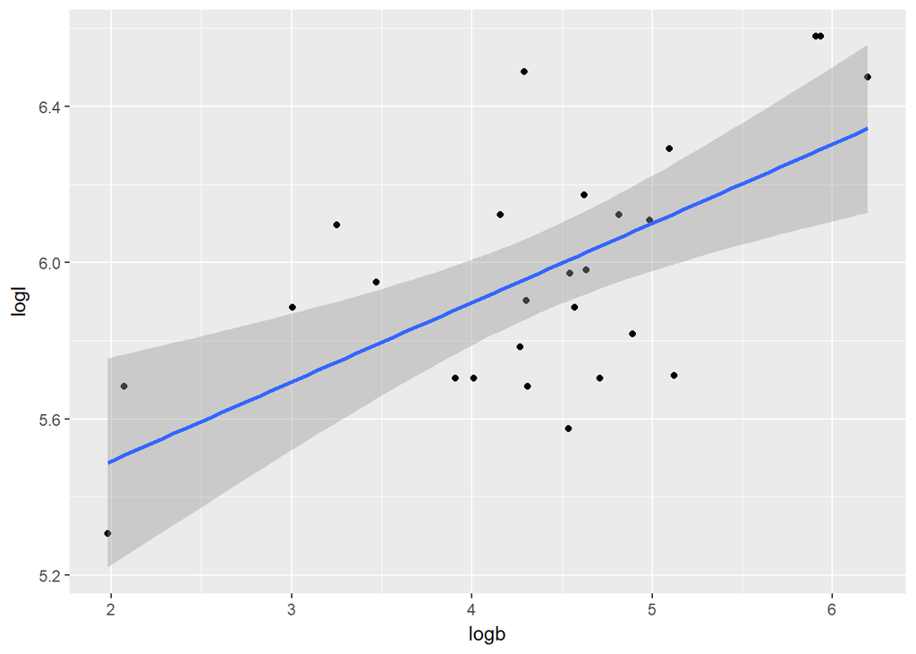

```r
g <- ggplot(data = d2, aes(x = logb, y = logl))
g <- g + geom_point()
g <- g + geom_smooth(method = "lm", formula = y ~ x)
g
```

```r
beta1 <- cor(logb, logl) * (sd(logl)/sd(logb))
beta1
```

```
## [1] 0.2028543
```

```r
logfit<-lm(logl~logb)
summary(logfit)
```

```
##
## Call:
## lm(formula = logl ~ logb)
##
## Residuals:
##      Min       1Q   Median       3Q      Max
## -0.43044 -0.18029 -0.01211  0.17548  0.53196
##
## Coefficients:
##             Estimate Std. Error t value Pr(>|t|)
## (Intercept)  5.08650    0.22413  22.694  < 2e-16 ***
## logb         0.20285    0.05002   4.055 0.000458 ***
## ---
## Signif. codes:  0 '***' 0.001 '**' 0.01 '*' 0.05 '.' 0.1 ' ' 1
##
## Residual standard error: 0.2539 on 24 degrees of freedom
## Multiple R-squared:  0.4066, Adjusted R-squared:  0.3819
## F-statistic: 16.44 on 1 and 24 DF,  p-value: 0.0004583
```

```r
confint(logfit, 'logb', level=0.90)
```

```
##            5 %      95 %
## logb 0.1172695 0.2884391
```

I think this is the 90% ci for the slope

```r
confint(logfit, level=0.90)
```

```
##                   5 %      95 %
## (Intercept) 4.7030309 5.4699646
## logb        0.1172695 0.2884391
```

```r
ci <- predict(logfit, newdata = data.frame(Brain_Size_Species_Mean = log(d2$Brain_Size_Species_Mean)), interval = "confidence",
    level = 0.90)  # for a vector of values
head(ci)
```

```
##        fit      lwr      upr
## 1 5.879581 5.785763 5.973399
## 2 5.900212 5.809692 5.990732
## 3 5.488072 5.266574 5.709571
## 4 5.956641 5.871172 6.042110
## 5 5.952141 5.866501 6.037781
## 6 5.960662 5.875311 6.046013
```

```r
logfit<-lm(logl~logb)
h_hat <- predict(logfit, newdata = data.frame(Brain_Size_Species_Mean = log(d2$Brain_Size_Species_Mean)))
logdf <- data.frame(cbind(log(d2$Brain_Size_Species_Mean), log(d2$MaxLongevity_m), h_hat))
names(logdf) <- c("x", "y", "yhat")
head(logdf)
```

```
##          x        y     yhat
## 1 3.909620 5.703782 5.879581
## 2 4.011325 5.703782 5.900212
## 3 1.979621 5.306286 5.488072
## 4 4.289500 6.488597 5.956641
## 5 4.267317 5.784440 5.952141
## 6 4.309322 5.683580 5.960662
```

```r
logdf <- cbind(logdf, ci)
names(logdf) <- c("x", "y", "yhat", "CIfit", "CIlwr", "CIupr")
head(df)
```

```
##       x     y     yhat    CIfit    CIlwr    CIupr    PIfit    PIlwr
## 1 49.88 300.0 351.5919 351.5919 312.9621 390.2217 351.5919 179.0151
## 2 55.22 300.0 356.2853 356.2853 318.4280 394.1425 356.2853 183.8797
## 3  7.24 201.6 314.1155 314.1155 267.9467 360.2843 314.1155 139.6963
## 4 72.93 657.6 371.8507 371.8507 336.2051 407.4962 371.8507 199.9172
## 5 71.33 325.2 370.4444 370.4444 334.6229 406.2659 370.4444 198.4744
## 6 74.39 294.0 373.1339 373.1339 337.6445 408.6232 373.1339 201.2328
##      PIupr
## 1 524.1688
## 2 528.6908
## 3 488.5347
## 4 543.7841
## 5 542.4144
## 6 545.0350
```

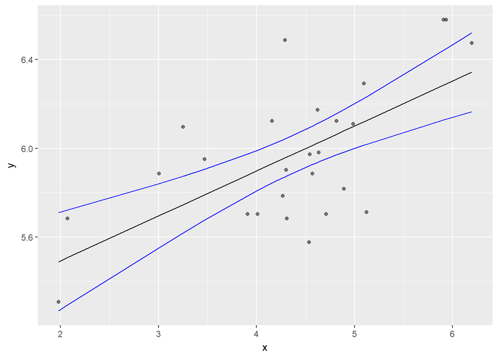

```r
g <- ggplot(data = logdf, aes(x = x, y = y))
g <- g + geom_point(alpha = 1/2)
g <- g + geom_line(aes(x = x, y = CIfit), colour = "black")
g <- g + geom_line(aes(x = x, y = CIlwr), colour = "blue")
g <- g + geom_line(aes(x = x, y = CIupr), colour = "blue")
g
```

```r
pi <- predict(logfit, newdata = data.frame(Brain_Size_Species_Mean = log(d2$Brain_Size_Species_Mean)), interval = "prediction",
    level = 0.90)  # for a vector of values
head(pi)
```

```
##        fit      lwr      upr
## 1 5.879581 5.435127 6.324035
## 2 5.900212 5.456443 6.343982
## 3 5.488072 5.000426 5.975719
## 4 5.956641 5.513874 6.399408
## 5 5.952141 5.509341 6.394941
## 6 5.960662 5.517918 6.403406
```

```r
logdf <- cbind(logdf, pi)
names(logdf) <- c("x", "y", "yhat", "CIfit", "CIlwr", "CIupr", "PIfit", "PIlwr",
    "PIupr")
head(logdf)
```

```
##          x        y     yhat    CIfit    CIlwr    CIupr    PIfit    PIlwr
## 1 3.909620 5.703782 5.879581 5.879581 5.785763 5.973399 5.879581 5.435127
## 2 4.011325 5.703782 5.900212 5.900212 5.809692 5.990732 5.900212 5.456443
## 3 1.979621 5.306286 5.488072 5.488072 5.266574 5.709571 5.488072 5.000426
## 4 4.289500 6.488597 5.956641 5.956641 5.871172 6.042110 5.956641 5.513874
## 5 4.267317 5.784440 5.952141 5.952141 5.866501 6.037781 5.952141 5.509341
## 6 4.309322 5.683580 5.960662 5.960662 5.875311 6.046013 5.960662 5.517918
##      PIupr
## 1 6.324035
## 2 6.343982
## 3 5.975719
## 4 6.399408
## 5 6.394941
## 6 6.403406
```

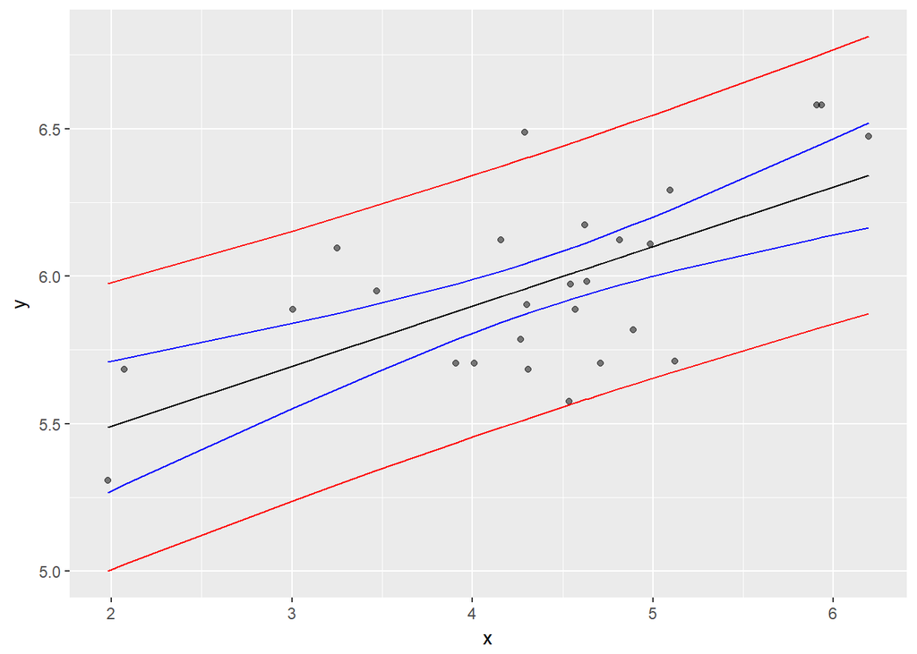

```r
g <- g + geom_line(data = logdf, aes(x = x, y = PIlwr), colour = "red")
g <- g + geom_line(data = logdf, aes(x = x, y = PIupr), colour = "red")
g
```

```r
pi <- predict(logfit, newdata = data.frame(log(d2$Brain_Size_Species_Mean) = 800), interval = "prediction",
    level = 0.90)  # for a single value
pi
```

I dont know what the problem here is I do not know how to make the legend I cant find the right things to make a color coated with the lines. I’m not sue which one is better, both do not look that normal and both have low p values. I think that the log one might be better because it has a lower standard error with the Residuals